# Laboratorio: brecha salarial y retorno a la educación

XS0100 Fundamentos de Teoría Estadística — II ciclo 2026

Autor/a

Prof. Christopher Torres Rojas

## Objetivos

- Aplicar pruebas de hipótesis para una media, para una diferencia de medias y para una diferencia de proporciones a datos de un mercado laboral.
- Estimar una regresión con una variable dicotómica y una covariable, e interpretar sus coeficientes como semielasticidades y elasticidades.
- Validar los supuestos del modelo y reconocer observaciones influyentes.

## Datos

La tabla `empleo` contiene una muestra aleatoria de 500 personas asalariadas:

| Variable | Descripción |
| --- | --- |
| `salario` | Salario por hora (colones) |
| `educacion` | Años de escolaridad aprobados |
| `experiencia` | Años de experiencia laboral |
| `sexo` | `Hombre` / `Mujer` |
| `zona` | `GAM` / `Fuera de la GAM` |
| `solidarista` | Afiliación a una asociación solidarista (`Si` / `No`) |

## Paso 1. Exploración de los datos

```r
empleo <- read.csv("empleo.csv")
empleo$sexo <- factor(empleo$sexo, levels = c("Hombre", "Mujer"))
str(empleo)
```

```
'data.frame':   500 obs. of  6 variables:
 $ salario    : int  7180 2391 6454 2441 2685 1650 10448 6221 11746 2907 ...
 $ educacion  : int  16 13 16 12 11 6 18 10 20 8 ...
 $ experiencia: int  21 12 9 4 14 6 40 45 23 20 ...
 $ sexo       : Factor w/ 2 levels "Hombre","Mujer": 1 1 1 1 1 2 2 2 1 1 ...
 $ zona       : chr  "GAM" "Fuera de la GAM" "GAM" "GAM" ...
 $ solidarista: chr  "No" "Si" "Si" "No" ...
```

**Preguntas**

1. ¿Qué indica que la media del salario sea mayor que la mediana?
2. Compare los histogramas del salario y de $\ln(\text{salario})$. ¿Cuál se parece más a una distribución normal?

**ImportanteInterpretación**

```r
library(dplyr)
empleo %>%
  group_by(sexo) %>%
  summarise(
    media = mean(salario, na.rm = TRUE),
    mediana = median(salario, na.rm = TRUE),
    desv = sd(salario, na.rm = TRUE)
  )
```

```
# A tibble: 2 × 4
  sexo   media mediana  desv
  <fct>  <dbl>   <int> <dbl>
1 Hombre 4401.    3819 2244.
2 Mujer  3888.    3577 1969.
```

**a)** En ambos grupos la media supera a la mediana: la distribución del salario es asimétrica a la derecha. Unos pocos salarios muy altos jalan la media hacia arriba, mientras que la mediana casi no se ve afectada por ellos.

**ImportanteInterpretación**

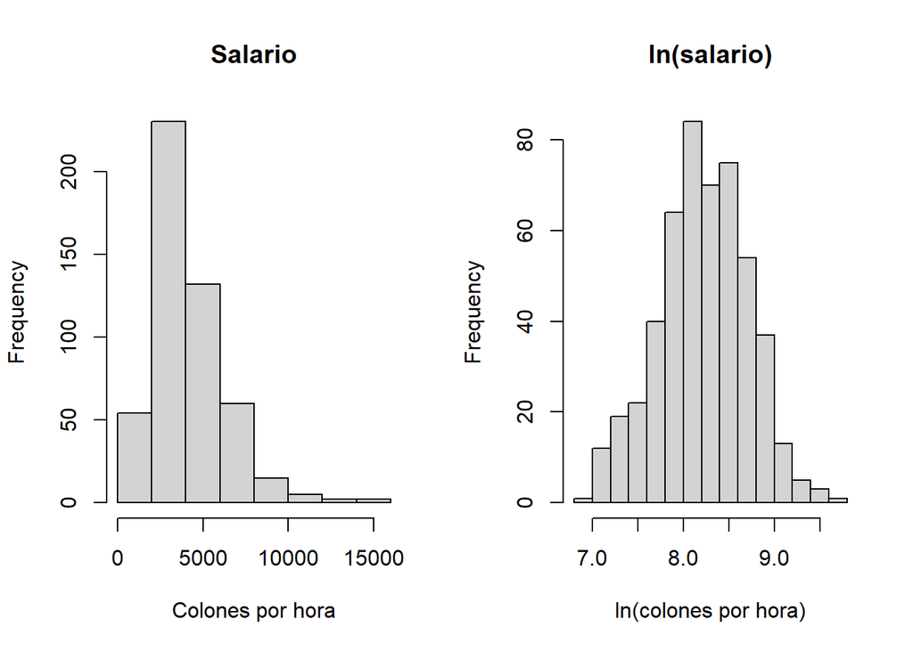

```r
# Histograma
par(mfrow = c(1, 2))
hist(empleo$salario, main = "Salario", xlab = "Colones por hora")
hist(log(empleo$salario), main = "ln(salario)", xlab = "ln(colones por hora)")
```

```r
par(mfrow = c(1, 1))
```

## Paso 2. Prueba para una media

Una cámara empresarial considera que 3500 colones por hora es el salario mínimo “competitivo” para atraer personal. ¿Hay evidencia de que el salario medio por hora supera ese valor?

**Preguntas**

1. Escriba $H_0$ y $H_1$, la fórmula del estadístico y su distribución bajo $H_0$. Compare el valor calculado “a mano” con el de `t.test()`. ¿Qué concluye?
2. En el paso 1 vimos que el salario no es normal. ¿Por qué la prueba $t$ sigue siendo aproximadamente válida con $n = 500$?

**ImportanteInterpretación**

**a)** $H_0\colon \mu \le 3500$ contra $H_1\colon \mu > 3500$, con
$$T = \frac{\bar X - \mu_0}{S/\sqrt{n}} \sim t_{n-1} \quad \text{bajo } H_0.$$

```r
mean(empleo$salario) #media
```

```
[1] 4178.722
```

```r
sd(empleo$salario) #desviacion
```

```
[1] 2142.024
```

```r
length(empleo$salario)  #n
```

```
[1] 500
```

$$T = \frac{\bar X - \mu_0}{S/\sqrt{n}} = \frac{4178.7 - 3500}{2142/\sqrt{500}} \approx 7.0852$$

P-Value:

```r
n <- length(empleo$salario)  #n

pt(7.0852, df = n - 1, lower.tail = FALSE)
```

```
[1] 2.378128e-12
```

```r
#Si H1: mu > valor, entonces lower.tail = FALSE
#Si H1: mu < valor, entonces lower.tail = TRUE
```

El cálculo a mano coincide con `t.test()`.

```r
t.test(empleo$salario, mu = 3500, alternative = "greater")
```

```
    One Sample t-test

data:  empleo$salario
t = 7.0852, df = 499, p-value = 2.378e-12
alternative hypothesis: true mean is greater than 3500
95 percent confidence interval:
 4020.861      Inf
sample estimates:
mean of x
 4178.722
```

Se rechaza $H_0$: el salario medio supera los 3500 colones por hora.

**b)** Por el teorema del límite central, $\bar X$ es aproximadamente normal con $n = 500$ aunque el salario sea asimétrico; además, $S$ converge a $\sigma$ (Slutsky). Por eso $T$ es aproximadamente $N(0, 1)$, prácticamente igual a una $t_{499}$.

## Paso 3. Diferencia de medias: brecha salarial bruta

**Preguntas**

1. Escriba el estadístico $F$ y su distribución bajo $H_0$. Según la prueba, ¿corresponde la prueba $t$ con varianza agrupada o la de Welch?
2. ¿Hay evidencia de que los hombres ganan más en promedio? ¿Cambia la conclusión según la prueba $t$ que se use?
3. Exprese la brecha en colones por hora y como porcentaje del salario medio de los hombres, e interprete el intervalo de confianza.

**ImportanteInterpretación**

**a)** $H_0\colon \sigma_H^2 = \sigma_M^2$ contra $H_1\colon \sigma_H^2 \neq \sigma_M^2$, con
$$F = \frac{S_H^2}{S_M^2} \sim F_{n_H - 1,\; n_M - 1} \quad \text{bajo } H_0.$$

```r
tapply(empleo$salario, empleo$sexo, mean)     # medias
```

```
  Hombre    Mujer
4401.276 3888.479
```

```r
tapply(empleo$salario, empleo$sexo, sd)       # desviaciones
```

```
  Hombre    Mujer
2244.094 1968.627
```

```r
tapply(empleo$salario, empleo$sexo, length)   # tamanos de muestra
```

```
Hombre  Mujer
   283    217
```

$$F = \frac{S_H^2}{S_M^2} = \frac{2244.09^2}{1968.63^2} \approx 1.2994$$

P-Value (bilateral; como $F > 1$, es el doble de la cola superior):

```r
2 * pf(1.2994, df1 = 283 - 1, df2 = 217 - 1, lower.tail = FALSE)
```

```
[1] 0.04277865
```

El cálculo a mano coincide con `var.test()`.

```r
var.test(salario ~ sexo, data = empleo)
```

```
    F test to compare two variances

data:  salario by sexo
F = 1.2994, num df = 282, denom df = 216, p-value = 0.04276
alternative hypothesis: true ratio of variances is not equal to 1
95 percent confidence interval:
 1.008632 1.667011
sample estimates:
ratio of variances
          1.299438
```

Como $p = 0.043 < 0.05$, se rechaza la igualdad de varianzas (por poco), así que corresponde la prueba de Welch.

Ojo: con $\alpha = 0.04$ no se rechazaría $H_0$ y correspondería la prueba con varianza agrupada. La decisión depende del nivel de significancia; por eso este se fija antes de ver los datos.

**b)** $H_0\colon \mu_H \le \mu_M$ contra $H_1\colon \mu_H > \mu_M$. Con la prueba de Welch, bajo $H_0$,
$$T = \frac{\bar X_H - \bar X_M}{\sqrt{S_H^2/n_H + S_M^2/n_M}} \approx t_\nu, \qquad \nu = \frac{\left(S_H^2/n_H + S_M^2/n_M\right)^2}{\dfrac{(S_H^2/n_H)^2}{n_H - 1} + \dfrac{(S_M^2/n_M)^2}{n_M - 1}}.$$

Con las medias, desviaciones y tamaños del inciso a):

$$T = \frac{4401.28 - 3888.48}{\sqrt{2244.09^2/283 + 1968.63^2/217}} \approx 2.716$$

Estadístico, grados de libertad y P-Value:

```r
vH <- 2244.09^2 / 283   # S_H^2 / n_H
vM <- 1968.63^2 / 217   # S_M^2 / n_M
(4401.28 - 3888.48) / sqrt(vH + vM)                   # estadistico T
```

```
[1] 2.715764
```

```r
(vH + vM)^2 / (vH^2 / (283 - 1) + vM^2 / (217 - 1))   # grados de libertad
```

```
[1] 489.0165
```

```r
pt(2.716, df = 489.02, lower.tail = FALSE)
```

```
[1] 0.003420783
```

El cálculo a mano coincide con `t.test()`:

```r
# Welch (R resta en el orden de los niveles: Hombre - Mujer)
t.test(salario ~ sexo, data = empleo, alternative = "greater")
```

```
    Welch Two Sample t-test

data:  salario by sexo
t = 2.7157, df = 489.02, p-value = 0.003423
alternative hypothesis: true difference in means between group Hombre and group Mujer is greater than 0
95 percent confidence interval:
 201.6198      Inf
sample estimates:
mean in group Hombre  mean in group Mujer
            4401.276             3888.479
```

```r
# Con varianza agrupada, para comparar
t.test(salario ~ sexo, data = empleo, var.equal = TRUE,
       alternative = "greater")
```

```
    Two Sample t-test

data:  salario by sexo
t = 2.6694, df = 498, p-value = 0.003924
alternative hypothesis: true difference in means between group Hombre and group Mujer is greater than 0
95 percent confidence interval:
 196.2242      Inf
sample estimates:
mean in group Hombre  mean in group Mujer
            4401.276             3888.479
```

Con Welch, $T \approx 2.716$, $\nu \approx 489$ y $p = 0.0034 < 0.05$: se rechaza $H_0$; los hombres ganan más en promedio. Con varianza agrupada, $t = 2.669$ y $p = 0.0039$: la conclusión no cambia (con muestras grandes, ambas pruebas se parecen).

**c)**

```r
4401.28 - 3888.48                     # brecha (colones por hora)
```

```
[1] 512.8
```

```r
(4401.28 - 3888.48) / 4401.28 * 100   # % del salario medio de los hombres
```

```
[1] 11.65116
```

```r
# IC 95% para mu_H - mu_M (Welch)
t.test(salario ~ sexo, data = empleo)$conf.int
```

```
[1] 141.7908 883.8019
attr(,"conf.level")
[1] 0.95
```

La brecha es de 512.8 colones por hora, el 11.7 % del salario medio de los hombres. Intervalo del 95 % (Welch): $[141.8;\ 883.8]$ colones, es decir, la brecha poblacional está plausiblemente entre unos 140 y 880 colones por hora.

## Antes de la regresión: coeficientes y elasticidades

La **elasticidad** de $Y$ respecto a $X$ es el cambio porcentual de $Y$ cuando $X$ aumenta un 1 %:
$$\varepsilon_{Y,X} = \frac{dY}{dX}\cdot\frac{X}{Y} = \frac{d\ln Y}{d\ln X} \approx \frac{\%\Delta Y}{\%\Delta X}.$$

La idea clave es que un cambio en logaritmos es un cambio *relativo*: $\Delta \ln Y \approx \Delta Y/Y$, y al multiplicarlo por 100 se obtiene un cambio porcentual. Por eso, la lectura de un coeficiente depende de si las variables entran en niveles o en logaritmos:

| Modelo | Ecuación | Si $X$ aumenta… | Elasticidad $\varepsilon_{Y,X}$ |
| --- | --- | --- | --- |
| Lineal | $Y = \beta_0 + \beta_1 X$ | 1 unidad: $Y$ cambia $\beta_1$ unidades | $\beta_1 X/Y$ |
| Log-lineal | $\ln Y = \beta_0 + \beta_1 X$ | 1 unidad: $Y$ cambia $\approx 100\,\beta_1\,\%$ | $\beta_1 X$ |
| Lineal-log | $Y = \beta_0 + \beta_1 \ln X$ | 1 %: $Y$ cambia $\approx \beta_1/100$ unidades | $\beta_1/Y$ |
| Log-log | $\ln Y = \beta_0 + \beta_1 \ln X$ | 1 %: $Y$ cambia $\approx \beta_1\,\%$ | $\beta_1$ |

- En el modelo **log-log**, $\beta_1$ *es* la elasticidad y es constante. En el **log-lineal**, $\beta_1$ se llama *semielasticidad*. En los demás modelos la elasticidad depende del punto donde se evalúe; lo usual es evaluarla en las medias muestrales.
- **Variable dicotómica** $D$ (0 o 1) en un modelo para $\ln Y$, por ejemplo $\ln Y = \beta_0 + \beta_1 X + \beta_2 D$: con $X$ fija, $Y_{D=1}/Y_{D=0} = e^{\beta_2}$, así que la diferencia porcentual exacta es $100\,(e^{\beta_2} - 1)\,\%$. Leerla como “$100\,\beta_2\,\%$” es solo una aproximación, aceptable cuando $|\beta_2|$ es pequeño: si $\beta_2 = 0.05$, el efecto es de 5.1 %, pero si $\beta_2 = 0.60$, es de 82.2 %, no de 60 %.
- En regresión múltiple cada coeficiente se interpreta *ceteris paribus*, es decir, manteniendo constantes las demás variables del modelo.

## Paso 4. Regresión: retorno a la educación y brecha condicional

Sea $D_{\text{mujer}} = 1$ si la persona es mujer y 0 si es hombre (en R, al incluir el factor `sexo` se crea automáticamente la variable `sexoMujer`).

**Preguntas**

**ImportanteInterpretación**

**a)**

```r
# Modelo 1: solo la variable dicotomica
m1 <- lm(log(salario) ~ sexo, data = empleo)
summary(m1)
```

```
Call:
lm(formula = log(salario) ~ sexo, data = empleo)

Residuals:
     Min       1Q   Median       3Q      Max
-1.16454 -0.31020 -0.00877  0.34027  1.43853

Coefficients:
            Estimate Std. Error t value Pr(>|t|)
(Intercept)  8.27730    0.02904 285.031  < 2e-16 ***
sexoMujer   -0.13642    0.04408  -3.095  0.00208 **
---
Signif. codes:  0 '***' 0.001 '**' 0.01 '*' 0.05 '.' 0.1 ' ' 1

Residual standard error: 0.4885 on 498 degrees of freedom
Multiple R-squared:  0.01887,   Adjusted R-squared:  0.0169
F-statistic: 9.577 on 1 and 498 DF,  p-value: 0.002081
```

**b)**

```r
# Modelo 2: educacion y sexo
m2 <- lm(log(salario) ~ educacion + sexo, data = empleo)
summary(m2)
```

```
Call:
lm(formula = log(salario) ~ educacion + sexo, data = empleo)

Residuals:
     Min       1Q   Median       3Q      Max
-1.58563 -0.29118  0.00717  0.26578  1.53258

Coefficients:
            Estimate Std. Error t value Pr(>|t|)
(Intercept)  7.38747    0.07228 102.202  < 2e-16 ***
educacion    0.07967    0.00607  13.124  < 2e-16 ***
sexoMujer   -0.23378    0.03874  -6.034 3.13e-09 ***
---
Signif. codes:  0 '***' 0.001 '**' 0.01 '*' 0.05 '.' 0.1 ' ' 1

Residual standard error: 0.4214 on 497 degrees of freedom
Multiple R-squared:  0.2714,    Adjusted R-squared:  0.2684
F-statistic: 92.55 on 2 and 497 DF,  p-value: < 2.2e-16
```

$$\widehat{\ln(\text{salario})} = 7.387 + 0.0797\,\text{educacion} - 0.2338\,D_{\text{mujer}}$$

- **Significancia individual.** Para cada coeficiente, $H_0\colon \beta_j = 0$ contra $H_1\colon \beta_j \neq 0$, con $t = \hat\beta_j/\operatorname{ee}(\hat\beta_j) \sim t_{497}$ bajo $H_0$. Educación: $t = 13.12$; sexo: $t = -6.03$ (columna `t value`). Ambos con $p < 0.001$: los dos regresores son significativos.
- **Significancia global.** $H_0\colon \beta_1 = \beta_2 = 0$ contra $H_1$: al menos uno es distinto de cero. $F = 92.55$ con $(2, 497)$ grados de libertad y $p < 0.001$: el modelo es significativo. Explica el 27.1 % de la variabilidad de $\ln(\text{salario})$ ($R^2 = 0.271$).

**c)**

```r
coef(m2)["educacion"]                           # semielasticidad
```

```
educacion
0.0796659
```

```r
100 * (exp(coef(m2)["educacion"]) - 1)          # efecto exacto (%)
```

```
educacion
 8.292521
```

```r
mean(empleo$educacion)                          # escolaridad promedio
```

```
[1] 11.7
```

```r
coef(m2)["educacion"] * mean(empleo$educacion)  # elasticidad en la media
```

```
educacion
0.9320911
```

```r
confint(m2)                                     # IC 95%
```

```
                  2.5 %      97.5 %
(Intercept)  7.24544857  7.52948404
educacion    0.06773924  0.09159257
sexoMujer   -0.30989687 -0.15765777
```

Con el sexo fijo, cada año adicional de escolaridad aumenta el salario en aproximadamente $100 \times 0.0797 = 7.97\,\%$ (exacto: $100\,(e^{0.0797} - 1) = 8.29\,\%$).

Elasticidad en la escolaridad promedio:
$$\varepsilon = \hat\beta_1 \cdot \bar x = 0.0797 \times 11.70 \approx 0.93$$
Es decir, un aumento de 1 % en los años de escolaridad se asocia con un salario 0.93 % mayor.

Intervalo del 95 % para $\beta_1$: $[0.068;\ 0.092]$, es decir, un retorno de entre 6.8 % y 9.2 % por año adicional de escolaridad.

**d)**

```r
100 * (exp(coef(m1)["sexoMujer"]) - 1)        # brecha bruta (%)
```

```
sexoMujer
-12.75222
```

```r
100 * (exp(coef(m2)["sexoMujer"]) - 1)        # brecha condicional (%)
```

```
sexoMujer
-20.84619
```

```r
tapply(empleo$educacion, empleo$sexo, mean)   # escolaridad media por sexo
```

```
  Hombre    Mujer
11.16961 12.39171
```

Brecha condicional: $100\,(e^{-0.2338} - 1) \approx -20.8\,\%$; con igual escolaridad, las mujeres ganan cerca de un 21 % menos. La brecha bruta del Modelo 1 es $100\,(e^{-0.1364} - 1) \approx -12.8\,\%$.

La brecha crece porque las mujeres de la muestra tienen más escolaridad (12.39 años contra 11.17): en la comparación bruta, su mayor educación compensa parte de la brecha. (La aproximación $100\,\hat\beta_2 = -23.4\,\%$ ya se aleja del valor exacto.)

## Paso 5. Validación de supuestos del Modelo 2

**ImportanteInterpretación**

**a)**

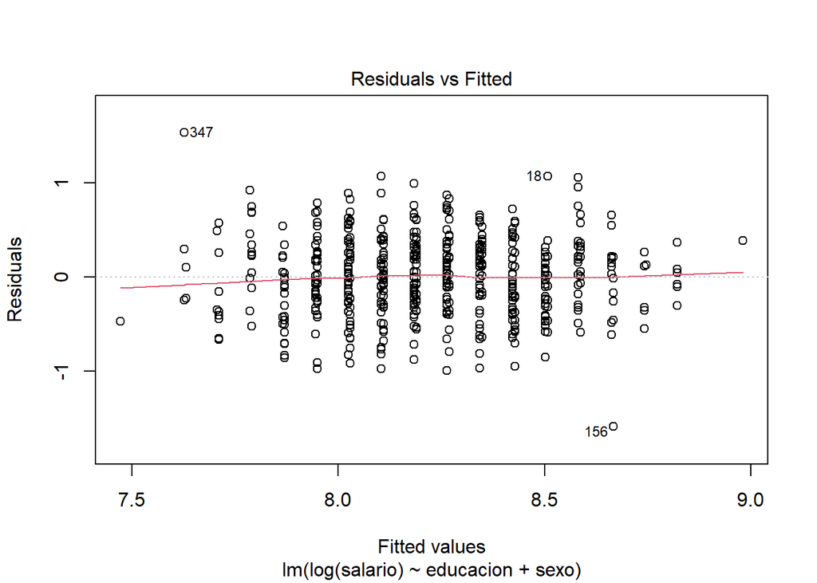

```r
library(lmtest)

plot(m2, 1)
```

```r
bptest(m2)   # H0: varianza constante (homocedasticidad)
```

```
    studentized Breusch-Pagan test

data:  m2
BP = 1.2624, df = 2, p-value = 0.532
```

Los residuos se distribuyen alrededor de cero, sin curvatura ni forma de embudo. Breusch–Pagan: $H_0$: la varianza de los errores es constante, contra $H_1$: la varianza depende de los regresores. $BP = 1.26$ con 2 grados de libertad y $p = 0.53$: no se rechaza la homocedasticidad. La independencia es razonable porque son personas distintas, seleccionadas al azar.

**b)**

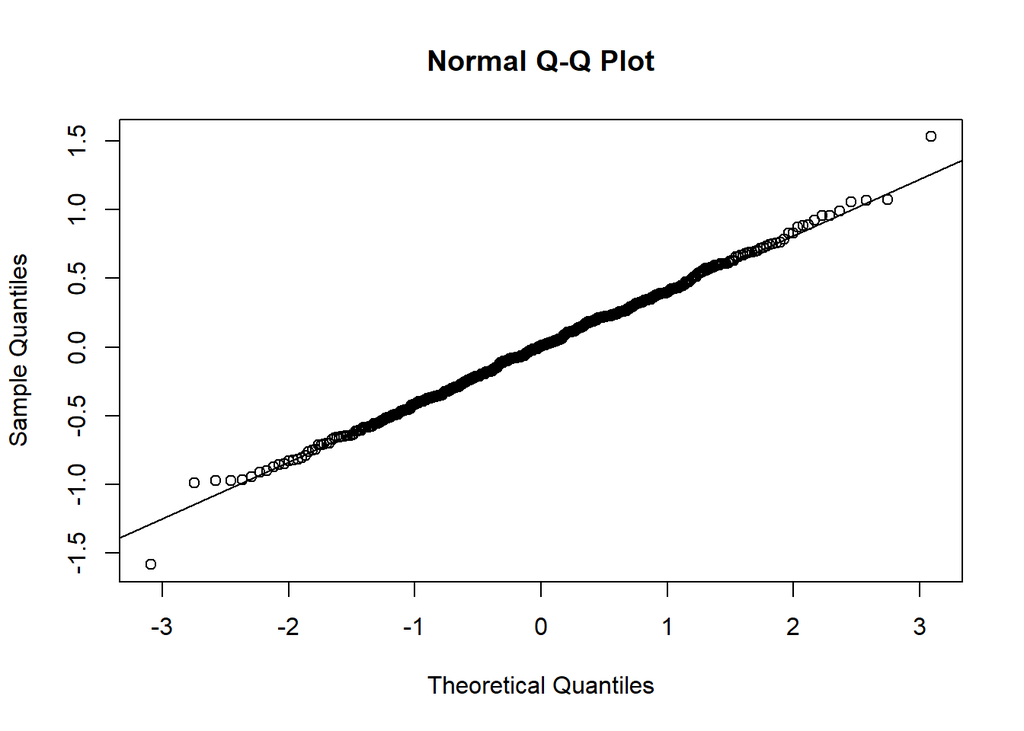

```r
qqnorm(resid(m2)); qqline(resid(m2))
```

```r
shapiro.test(resid(m2))   # H0: los errores son normales
```

```
    Shapiro-Wilk normality test

data:  resid(m2)
W = 0.99785, p-value = 0.7829
```

El gráfico QQ es casi recto y Shapiro–Wilk da $W = 0.998$ y $p = 0.78$: no se rechaza la normalidad. Aun con desviaciones moderadas, con $n = 500$ las pruebas $t$ y $F$ seguirían siendo aproximadamente válidas por el teorema del límite central.

**c)**

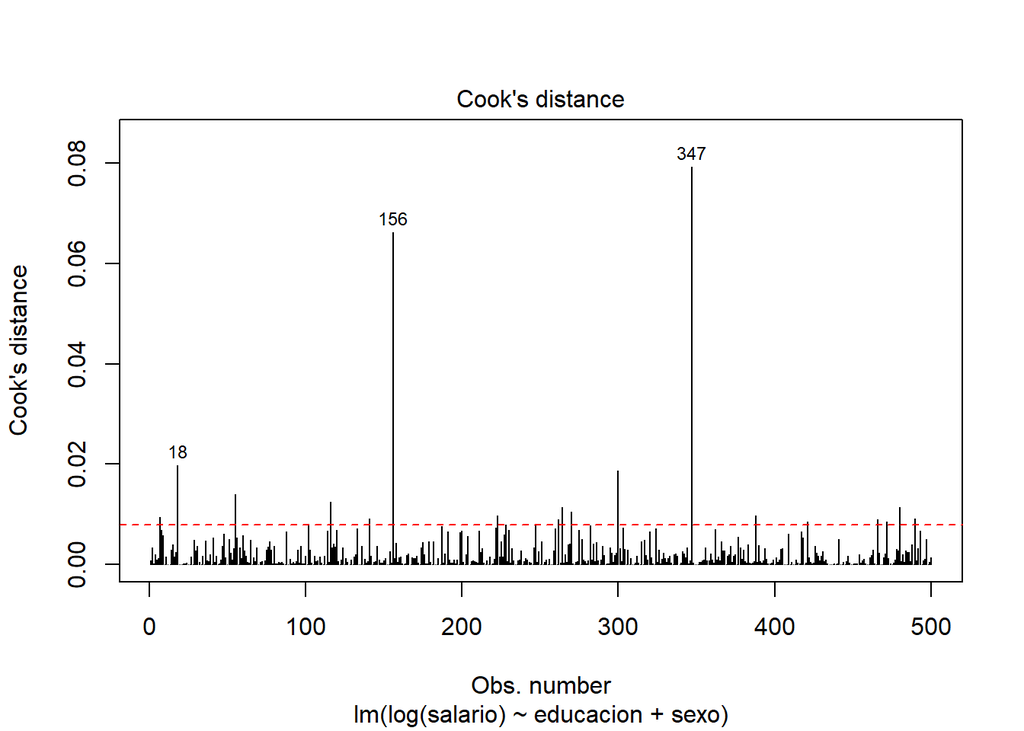

```r
plot(m2, 4)
abline(h = 4/n, col = "red", lty = 2)
```

```r
empleo[347,]
```

```
    salario educacion experiencia   sexo            zona solidarista
347    9500         3          30 Hombre Fuera de la GAM          No
```

```r
empleo[156,]
```

```
    salario educacion experiencia  sexo zona solidarista
156    1190        19           2 Mujer  GAM          No
```

Veinte observaciones superan $4/n = 0.008$, pero dos sobresalen: la fila 347 (hombre, 3 años de escolaridad, 30 de experiencia, 9500 colones por hora) y la fila 156 (mujer, 19 años de escolaridad, 2 de experiencia, 1190 colones por hora).

```r
#Eliminando esas observaciones atípicas
m2.1 <-  lm(log(salario) ~ educacion + sexo, data = empleo[-c(347,156),])
summary(m2.1)
```

```
Call:
lm(formula = log(salario) ~ educacion + sexo, data = empleo[-c(347,
    156), ])

Residuals:
     Min       1Q   Median       3Q      Max
-0.98360 -0.29085  0.00623  0.26600  1.08325

Coefficients:
             Estimate Std. Error t value Pr(>|t|)
(Intercept)  7.327113   0.071251 102.835  < 2e-16 ***
educacion    0.084570   0.005977  14.149  < 2e-16 ***
sexoMujer   -0.226703   0.037731  -6.008 3.63e-09 ***
---
Signif. codes:  0 '***' 0.001 '**' 0.01 '*' 0.05 '.' 0.1 ' ' 1

Residual standard error: 0.4101 on 495 degrees of freedom
Multiple R-squared:    0.3, Adjusted R-squared:  0.2972
F-statistic: 106.1 on 2 and 495 DF,  p-value: < 2.2e-16
```

Sin ellas, $\hat\beta_1$ pasa de 0.0797 a 0.0846 y $\hat\beta_2$, de $-0.2338$ a $-0.2267$: cambios pequeños, con las mismas conclusiones.

**En la práctica no se eliminan solo por ser influyentes. Hay que verificar si son errores de digitación y, si no lo son, reportar los resultados con y sin ellas.**

**d)**

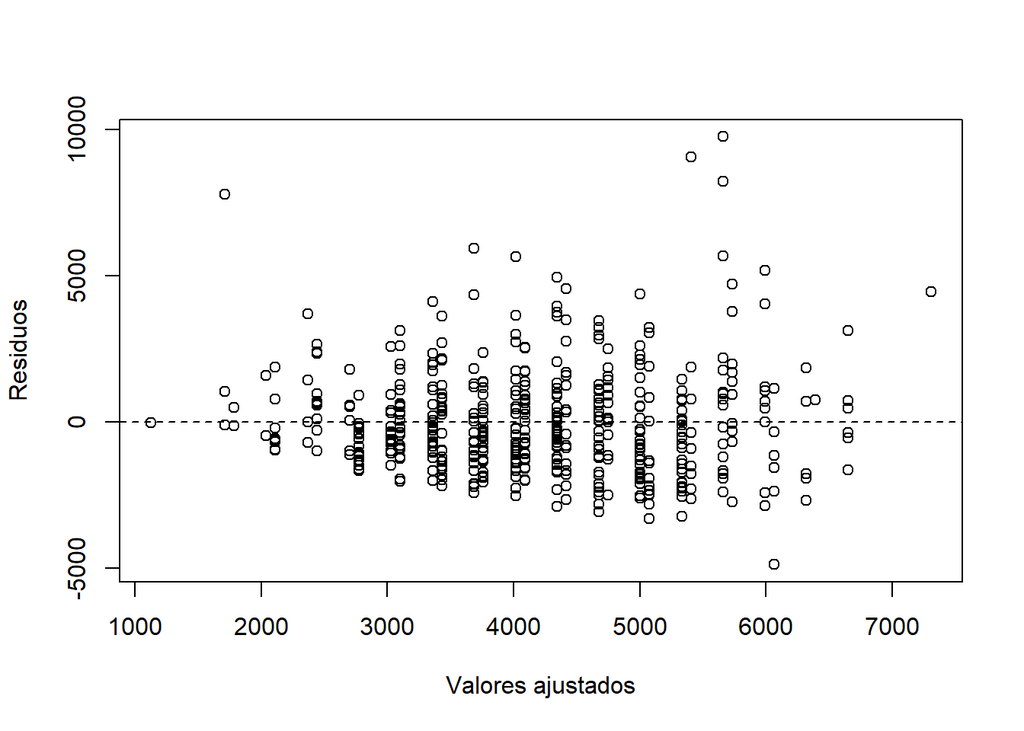

```r
m3 <- lm(salario ~ educacion + sexo, data = empleo)   # salario en niveles
plot(fitted(m3), resid(m3), xlab = "Valores ajustados", ylab = "Residuos")
abline(h = 0, lty = 2)
```

```r
bptest(m3)
```

```
    studentized Breusch-Pagan test

data:  m3
BP = 15.032, df = 2, p-value = 0.0005444
```

```r
shapiro.test(resid(m3))
```

```
    Shapiro-Wilk normality test

data:  resid(m3)
W = 0.91447, p-value = 3.36e-16
```

```r
coef(m3)["educacion"]    # pendiente de educacion
```

```
educacion
 329.2352
```

```r
mean(empleo$educacion)   # media de X
```

```
[1] 11.7
```

```r
mean(empleo$salario)     # media de Y
```

```
[1] 4178.722
```

En niveles, la dispersión de los residuos crece con los valores ajustados (forma de embudo): $BP = 15.03$ y $p < 0.001$ (heterocedasticidad). Además, Shapiro–Wilk da $W = 0.914$ y $p < 0.001$ (no normalidad).

Elasticidad en las medias (fila “Lineal” del recuadro):
$$\varepsilon = \hat\beta_1 \cdot \frac{\bar x}{\bar y} = 329.2 \times \frac{11.70}{4178.7} \approx 0.92$$

Es parecida a la del Modelo 2 (0.93), pero solo el modelo en logaritmos cumple los supuestos, y sus coeficientes se leen directamente como cambios porcentuales.

Desde un enfoque completamente estadístico usar transformaciones como $\ln$ estabiliza la varianza de los residuales y arregla el cumplimiento del supuesto de normalidad.

Desde un punto de vista económico las variables economicas suelen ser asimétricas positivas, además de su relación directa con el concepto de elasticidad.